# Multi-Response Phylogenetic Mixed Modelling: a tutorial

Ben Halliwell, Luke Yates & Barbara Holland

### Introduction

This tutorial is associated with the article “Multi-Response Phylogenetic Mixed Modelling: Theory, Implementation and Recommendations”

by

Ben Halliwell, Luke Yates & Barbara Holland

In this tutorial we will cover how to implement multi-response (MR) phylogenetic mixed models (PMM) in two popular R packages, MCMCglmm and brms. While frequentist implementations of the PMM are available (e.g., pglmm() in the “phyr” package), we advocate for a Bayesian approach due to 1) greater flexibility in fitting non-Gaussian response traits 2) suitability for estimating variance components associated with structured random effects; 3) the ability to sample conditional multivariate distributions, avoiding intractable integration problems faced by frequentist techniques.

Throughout this tutorial, we explore a low dimensional example (tree with only 5 taxa) in order to show full workings of the matrix manipulations that underlie the models specified. This is for the sake of exposition only; analyses of the form presented will typically require much higher phylogenetic replication to produce reliable estimates of, for example, phylogenetic correlations (Housworth et al. 2004). Thus, while the mathematical workings presented follow a 5 taxa example, model outputs are based on analyses from simulations including 250 taxa.

### Model 1 - Univariate Gaussian

#### Model Explanation

For the case of a single Gaussian trait, our response variable, $\mathbf{y}$, is modeled directly as a linear combination of the fixed effects $\boldsymbol{\mu}$, a phylogenetic random effect, $\mathbf{b}$, and residual variance, $\mathbf{e}$.

$$\begin{eqnarray}
\mathbf{y} &=& \boldsymbol{\mu} + \mathbf{b} + \mathbf{e}\\[2mm]
\end{eqnarray}$$

where $\mu$ represents,

$$\begin{eqnarray}
\boldsymbol{\mu} = \beta_0 + \beta_1\boldsymbol{X_1} + \ldots +
\beta_{k}\boldsymbol{X_{k}}
\end{eqnarray}$$

In order to capture the expected influence of co-ancestry on $y$, (similar values among closely related taxa), the distribution of our random effect, $b$, is multivariate normal, with mean 0 and (co)variance given by $\sigma_{b}C$,

$$\begin{eqnarray}
\mathbf{b} &\sim& \mbox{MVN}(0, \sigma^2_{b}C)\\
\end{eqnarray}$$

Here, $C$ is a fixed $n\times n$ phylogenetic VCV matrix, where $n$ is the number of taxa in the tree, and $\sigma_{b}$, the phylogenetic variance, is a scalar to be estimated by the model. This model therefore takes as input a phylogeny (topology and branch lengths), which is assumed to be known without error. The $C$ matrix is derived from the similarity matrix of the phylogeny. This gives the expected (co)variance among taxa in $y$ assuming BM evolution.

$$\begin{eqnarray}
C &=&
\begin{pmatrix}C_{11} & C_{12} & \ldots & C_{1n} \\
C_{21} & C_{22} & \ldots & C_{2n} \\
\vdots & \vdots & \ddots & \vdots \\
C_{n1} & C_{n2} & \ldots & C_{nn} \\
\end{pmatrix}
\end{eqnarray}$$

In contrast, the identity matrix $I$ (an $n\times n$ matrix with 1 in all diagonal elements and 0 in all off-diagonal elements) encodes independent residual error associated with each observation (taxon) in the distributional statement for the errors:

$$\begin{eqnarray}
\mathbf{e} &\sim& \mbox{MVN}(0, \sigma^2_{e}I)\\
\end{eqnarray}$$

#### Example

Consider the following 5-taxon phylogeny with similarity between taxa shown on the x axis:

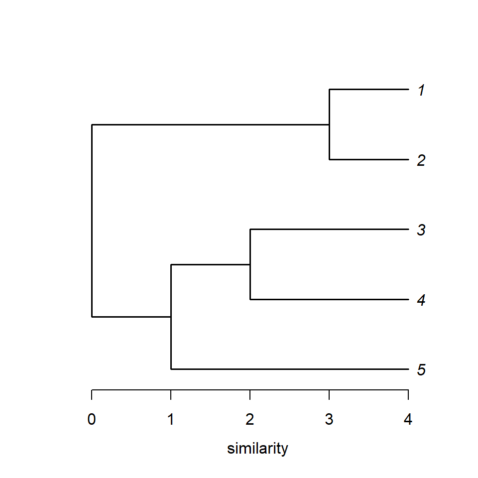

```r
toy.phy <- read.tree(text='((5:3, (4:2, 3:2):1):1, (2:1, 1:1):3);')
plot(toy.phy, label.offset=0.1, edge.width=1.5)
axis(1, at = seq(0,4,by=1), labels = seq(0,4,by=1), line = 0.5)
title(xlab="similarity")
```

The identity matrix $I$ for this model is:

$$\begin{eqnarray}
I &=&
\begin{pmatrix} 1 & 0 & 0 & 0 & 0 \\
0 & 1 & 0 & 0 & 0 \\
0 & 0 & 1 & 0 & 0 \\
0 & 0 & 0 & 1 & 0 \\
0 & 0 & 0 & 0 & 1 \\
\end{pmatrix}
\end{eqnarray}$$

#### Data Simulation and Model Specification

Implementing these models in R is fairly straight forward in both MCMCglmm and brms. But first, let’s simulate some data. To simulate data under this model, we simply construct our variable, $y$, from the linear combination of predictors specified by the model, by supplying vectors of length $n$ for each of the quantities $\mu$, $b$, and $e$. For Gaussian variables this can be done directly. For non-Gaussian variables simulation is a two-step process where $b$ and $e$ are simulated on the link scale to determine the mean and the response values themselves are subsequently drawn from the appropriate distribution (see section 3). In this example, we will simulate from an intercept only model ($\mu$ = $\beta_0$).

```r
## SIMULATION

# simulate tree
n = 250 # number of species
phy <- geiger::sim.bdtree(b=1, d=0, stop="taxa", n=n, extinct=FALSE)

# create VCV matrix from tree, scale to correlation matrix with corr = T
C = ape::vcv.phylo(phy, corr = T)

# identity matrix
I = diag(n)

# fixed effects (intercept only)
u = 0

# phylogenetic variance
sigma_b = 1

# residual variance
sigma_e = 1

# simulate phylogenetic random effects as one draw from a MVN
b = MASS::mvrnorm(1,rep(0,n),sigma_b*C)

# simulate residuals
e = MASS::mvrnorm(1,rep(0,n),sigma_e*I)

# construct response from the linear predictor
y = u + b + e

# generate df
animal <- phy$tip.label # "animal" is a reserved term in MCMCglmm for taxon ID
d <- data.frame(animal,y)

## PLOT HEATMAP of traits against phy
```

With our tree and trait data simulated, we can now fit the model:

```r
## MCMCglmm
p.m.1 <- list(G = list(G1 = list(V = 1, nu = 0.002)),
              R = list(V = 1, nu = 0.002))
m.1 <- MCMCglmm(y ~ 1,
                random = ~animal,
                pedigree = phy,
                family = c("gaussian"),
                data = d,
                prior = p.m.1,
                nitt = 210000, burnin = 10000, thin = 200,
                pr = TRUE, verbose = F)


## BRMS
p.b.1 <- set_prior("student_t(3, 0, 2.5)", class = c("sd","sigma","Intercept"), lb = c(0,0,NA))
b.1 <- brm(y ~ 1 + (1|gr(animal, cov = C)),
            data = d,
            prior = p.b.1,
            family = gaussian(),
            data2 = list(C = C),
            cores = 2, chains = 2, iter = 6000, thin = 3)
```

#### Model Syntax (MCMCglmm vs. brms)

The code above fits the same model in MCMCglmm and brms. In MCMCglmm, `animal` is a reserved term used to identify individuals/taxa in a quantitative genetic/phylogenetic analysis. The random effect specification `~animal` instructs MCMCglmm to fit a random effect at the individual/taxon level with covariance structure supplied via the `pedigree` argument. For `pedigree`, MCMCglmm accepts a `phylo` object directly and performs the necessary steps to derive the matrix $C$ under the hood. The remaining arguments specify the data, the priors, and the sampler settings. The argument `pr` is used to retain the posterior distribution of random effects.

In brms, the phylogenetic random effect can be encoded in the style of lme4 `(1|gr(animal, cov = C))`, where `(1|x)` specifies random intercepts and `gr(animal, cov = C)` encodes the phylogenetic group structure.

It is not necessary to specify a prior to fit this model in either MCMCglmm or brms because sensible defaults are used automatically. However, we choose to explicitly specify (current default) priors to ensure repeatability, should the defaults change in the future. A key difference between these packages is the implemented Monte Carlo sampling method and the subsequent choice of priors. MCMCglmm is based on Gibbs sampling, which requires conjugate prior distributions to reduce sampling time through analytic computations. brms uses Hamiltonian Monte Carlo sampling which is an efficient hybrid of optimisation and sampling approaches that places no restrictions on the choice of prior.

#### Convergence Diagnostics

Basic convergence diagnostics are easily obtained for each package. As a first step, it is advisable to perform visual checks of the MCMC sample trace to confirm adequate mixing and stationary chains.

```r
# visual check for convergence in MCMC chains
plot(m.1$VCV)
plot(b.1)
```

Another standard indicator of sampling adequacy is the effective sample size (ESS) of each parameter estimate. In the presence of auto-correlation between MCMC samples, the ESS will be reduced relative to the thinned sample number, with low ESS indicating poor sampling. ESS is reported in the model summary for both MCMCglmm and brms.

```r
# model summaries
summary(m.1)
b.1
```

We can also check the auto-correlation in MCMC draws generated by the Gibbs sampler in MCMCglmm. This is generally not necessary for models fit in brms, as the Hamiltonian sampler ensures low dependence between samples.

```r
# calculate autocorrelation in MCMC draws (generally unnecessary for brms due to Hamiltonian sampler)
autocorr(m.1$VCV)
```

```r
# calculate potential scale reduction factors for each
# variance component over multiple MCMC chains
m.1.2 <- mclapply(1:2, function(i) {
  MCMCglmm(y ~ 1,
           random = ~animal,
           pedigree = phy,
           family = c("gaussian"),
           data = d,
           prior = p.m.1,
           nitt = 350000, burnin = 50000, thin = 300,
           pr = TRUE, verbose = FALSE)
}, mc.cores=1)

m.1.2 <- lapply(m.1.2, function(m) m$VCV)
m.1.2 <- do.call(mcmc.list, m.1.2)
m.1.2 %>% as.matrix %>% Rhat

plot(m.1.2)
```

#### Model Validation

```r
# posterior predictive checks
b.1 %>% pp_check(nsamples = 100)
```

For MCMCglmm, posterior predictive checks can be obtained with slightly more effort (see MCMCglmm course notes)

```r
# posterior predictive checks
rep <- 100
pred <- matrix(nrow = rep, ncol = 250)
for (i in 1:rep) {
pred[i,] <- rnorm(250, (m.1$X %*% m.1$Sol[i,])@x, sqrt(sum(m.1$VCV[i,])))
}
obs <- d$y
pp_check(obs, pred, ppc_dens_overlay)
```

#### Inference

Having fit and validated our model, the next step is to make inferences on the parameters estimated. In the Bayesian paradigm, inference is based upon summary statistics of the posterior distributions of the model parameters. For example, hypothesis tests can be performed by evaluating whether a CI (e.g. 95%) of the posterior of a parameter crosses zero. This is easily evaluated from the mode, summary. However, we note that, while intercept estimates are directly comparable, MCMCglmm reports variance components where-as brms reports these quantities as standard deviations. As our simulations also specify standard deviations, we will re-scale estimates from MCMCglmm by calculating posterior means from the `sqrt` of MCMC samples.

```r
# summary
summary(m.1)
summary(b.1)

# intercept
summary(m.1)$solutions
summary(b.1)[["fixed"]]

# phylogenetic variance (sigma_b)
m.1$VCV[,"animal"] %>% sqrt %>% quantile(probs = c(0.025,0.5,0.975))
summary(b.1)[["random"]]

# residual variance (sigma_e)
m.1$VCV[,"units"] %>% sqrt %>% quantile(probs = c(0.025,0.5,0.975))
summary(b.1)[["spec_pars"]]
```

#### Phylogenetic Signal

An estimate of phylogenetic signal, the amount of variation in a trait explained by / attributed to the phylogenetic relationship between species, in $\mathbf{y}$ can be calculated as

$$\begin{eqnarray} \label{eq_h2}
h^2 = \sigma^2_{b}/(\sigma^2_{b}+\sigma^2_{e})
\end{eqnarray}$$

```r
# MCMCglmm
(m.1$VCV[,"animal"]/(m.1$VCV[,"animal"]+m.1$VCV[,"units"])) %>% quantile(probs=c(0.025,0.5,0.975))

# brms (clean this up)
b.1 %>% as_tibble() %>%
        dplyr::select(sigma_b = sd_animal__Intercept, sigma_e = sigma) %>%
        mutate(h2 = sigma_b^2/(sigma_b^2 + sigma_e^2)) %>%
        pull(h2) %>% quantile(probs=c(0.025,0.5,0.975))
```

We can also confirm that $h^2$ from our PMM is estimating the same quantity as the MLE of lambda from an equivalent pgls model.

```r
## compare to MLE of lambda from PGLS
comp_dat <- comparative.data(phy, d, animal, vcv=TRUE)
mod <- pgls(y ~ 1, data = comp_dat, lambda = "ML")
summary(mod)$param["lambda"]
```

### Model 2 - Multi-Response Gaussian

#### Model Explanation

In a multi-response (MR) implementation, response variables are modelled jointly, allowing both phylogenetic and independent (co)variances to be estimated. A MR-PMM with two Gaussian response variables takes the form,

$$\begin{eqnarray}
\begin{pmatrix}\mathbf{y}_1 \\
\mathbf{y}_2 \end{pmatrix} &=&
\begin{pmatrix}\boldsymbol{\mu}_1 + \mathbf{b}_1 + \mathbf{e}_1 \\
\boldsymbol{\mu}_2 + \mathbf{b}_2 + \mathbf{e}_2
\end{pmatrix}\\
\end{eqnarray}$$

where fixed effects are expressed as a linear combination of predictors,

$$\begin{eqnarray}
\begin{pmatrix}\boldsymbol{\mu}_1 \\ \boldsymbol{\mu}_2 \end{pmatrix}
&=&
\begin{pmatrix}\beta_{0,1}\mathbf{1} + \beta_{1,1}\boldsymbol{X_{1,1}} +
\ldots + \beta_{k,1}\boldsymbol{X_{k,1}} \\
\beta_{0,2}\mathbf{1} + \beta_{1,2}\boldsymbol{X_{1,2}} +
\ldots + \beta_{k,2}\boldsymbol{X_{k,2}}
\end{pmatrix}\\
\end{eqnarray}$$

With this design, the phylogenetic random effects must also be realised jointly as a multivariate normal, with variance given by $\Sigma^{\mathrm{phy}} \otimes C$, the Kronecker product of a trait-level correlation matrix $\Sigma^{\mathrm{phy}}$ and the phylogenetic VCV matrix, $C$. With $m$ traits (response variables) and $n$ taxa in the phylogeny, $\Sigma^{\mathrm{phy}} \otimes C$ is an $mn\times mn$ cross-covariance matrix containing phylogenetic (co)variances for all traits as well as between all traits. Thus, the phylogenetic random effects and independent residuals are drawn from multivariate normal distributions,

$$\begin{eqnarray}
\begin{pmatrix}\mathbf{b}_1 , \mathbf{b}_2 \\ \end{pmatrix}
&\sim& \mbox{MVN}(0, \Sigma^{\mathrm{phy}} \otimes C)\\
\begin{pmatrix}\mathbf{e}_1 , \mathbf{e}_2 \\ \end{pmatrix}
&\sim& \mbox{MVN}(0, \Sigma^{\mathrm{ind}} \otimes I)\\[2mm]
\Sigma &=& \Sigma^{\mathrm{phy}} \otimes C +
\Sigma^{\mathrm{ind}} \otimes I
\end{eqnarray}$$

Notice that the two taxon-level variance structures we encountered in the univariate case above ($C$ and $I$) remain, but we must now also consider trait-level covariance operating at both the phylogenetic and independent level. This is achieved via the Kronecker operation. Let’s break it down.

$\Sigma^{\mathrm{phy}}$ is an $m\times m$ phylogenetic trait-level VCV matrix and $m$ is the number of response traits in the model,

$$\begin{eqnarray}
\Sigma^{\mathrm{phy}}
=
\begin{pmatrix}\Sigma^{\mathrm{phy}}_{11} &
\Sigma^{\mathrm{phy}}_{12} & \ldots & \Sigma^{\mathrm{phy}}_{1m}
\\
\Sigma^{\mathrm{phy}}_{21} &
\Sigma^{\mathrm{phy}}_{22} & \ldots & \Sigma^{\mathrm{phy}}_{2m}
\\
\vdots & \vdots & \ddots & \vdots \\
\Sigma^{\mathrm{phy}}_{m1} &
\Sigma^{\mathrm{phy}}_{m2} & \ldots & \Sigma^{\mathrm{phy}}_{mm}
\\ \end{pmatrix}
&=&
\begin{pmatrix}(\sigma^{\mathrm{{phy}}}_1)^2 &
\sigma^{\mathrm{{phy}}}_1\sigma^{\mathrm{{phy}}}_2\rho^{\mathrm{{phy}}}_{12}
&
\ldots &
\sigma^{\mathrm{{phy}}}_1\sigma^{\mathrm{{phy}}}_m\rho^{\mathrm{{phy}}}_{1m}
\\
\sigma^{\mathrm{{phy}}}_2\sigma^{\mathrm{{phy}}}_1\rho^{\mathrm{{phy}}}_{21}
&
(\sigma^{\mathrm{phy}}_2)^2 &
\ldots &
\sigma^{\mathrm{{phy}}}_2\sigma^{\mathrm{{phy}}}_m\rho^{\mathrm{{phy}}}_{2m}
\\
\vdots & \vdots & \ddots & \vdots \\
\sigma^{\mathrm{{phy}}}_m\sigma^{\mathrm{{phy}}}_1\rho^{\mathrm{{phy}}}_{m1}
&
\sigma^{\mathrm{{phy}}}_m\sigma^{\mathrm{{phy}}}_2\rho^{\mathrm{{phy}}}_{m2}
&
\ldots &
(\sigma^{\mathrm{phy}}_m)^2 \\ \end{pmatrix}\\[2mm]
\end{eqnarray}$$

such that elements of $\Sigma^{\mathrm{phy}}$ have the general form,

$$\begin{eqnarray}
\Sigma^{\mathrm{{phy}}}_{ij} =
\sigma^{\mathrm{{phy}}}_i\sigma^{\mathrm{{phy}}}_j\rho^{\mathrm{{phy}}}_{ij}
\\
\end{eqnarray}$$

Similarly, the covariance matrix for the independent residual errors, $\Sigma^{\mathrm{ind}} \otimes I$, is:

$$\begin{eqnarray}
\Sigma^{\mathrm{ind}} \otimes I
&=&
\begin{pmatrix} \Sigma^{\mathrm{ind}}_{11}I &
\Sigma^{\mathrm{ind}}_{12}I \\
\Sigma^{\mathrm{ind}}_{21}I &
\Sigma^{\mathrm{ind}}_{22}I \\
\end{pmatrix}
&=&
\begin{pmatrix} \Sigma^{\mathrm{ind}}_{11}
\left(\begin{smallmatrix}
1 & 0 & 0 & 0 & 0 \\
0 & 1 & 0 & 0 & 0 \\
0 & 0 & 1 & 0 & 0 \\
0 & 0 & 0 & 1 & 0 \\
0 & 0 & 0 & 0 & 1 \\
\end{smallmatrix}\right) &
\Sigma^{\mathrm{ind}}_{12}
\left(\begin{smallmatrix}
1 & 0 & 0 & 0 & 0 \\
0 & 1 & 0 & 0 & 0 \\
0 & 0 & 1 & 0 & 0 \\
0 & 0 & 0 & 1 & 0 \\
0 & 0 & 0 & 0 & 1 \\
\end{smallmatrix}\right)\\
\Sigma^{\mathrm{ind}}_{21}
\left(\begin{smallmatrix}
1 & 0 & 0 & 0 & 0 \\
0 & 1 & 0 & 0 & 0 \\
0 & 0 & 1 & 0 & 0 \\
0 & 0 & 0 & 1 & 0 \\
0 & 0 & 0 & 0 & 1 \\
\end{smallmatrix}\right)&
\Sigma^{\mathrm{ind}}_{22}
\left(\begin{smallmatrix}
1 & 0 & 0 & 0 & 0 \\
0 & 1 & 0 & 0 & 0 \\
0 & 0 & 1 & 0 & 0 \\
0 & 0 & 0 & 1 & 0 \\
0 & 0 & 0 & 0 & 1 \\
\end{smallmatrix}\right)\\
\end{pmatrix}
\end{eqnarray}$$

**N.B. This example is purely for illustrative purposes. The parameters of this model are not estimable with such low phylogenetic replication (n = 5 taxa). However, the low dimension of $A$ and $I$ allow us to explicitly show the working of matrix manipulations.**

#### Data Simulation and Model Specification

With multiple response variables, we must now consider covariance between responses at both the phylogenetic and independent level. To incorporate this into our data simulations, we must specify the relevant (co)variance structures for our random effects and independent errors.

```r
## SIMULATE DATA

# number of traits
m = 2

# fixed effects (intercepts for each trait)
u = c(0,0)

# Sigma_phy is the m x m phylogenetic trait-level covariance matrix,
# i.e., Sigma_phy specifies the phylogenetic variance in each trait (diagonals) as well as the phylogenetic covariance between traits (off-diagonals).
# To construct Sigma_phy, we first define its (co)variance components.
sig.b <- c(b11 = 1, b22 = 1) # sqrt of the phylogenetic variances for each trait; set to 1 so sigma = sigma^2
cor.b.12 = 0.5 # phylogenetic correlation coefficient between traits 1 and 2
Bcor <- matrix(c(c(1,cor.b.12), c(cor.b.12,1)),m,m, byrow = T) # phylogenetic correlation matrix
Sigma_phy <- matrix(kronecker(sig.b, sig.b),m,m)*Bcor # Construct Sigma_phy as point-wise product.
# N.B. Kronecker used in line above just for ease of matrix formatting. Do not confuse with Kronecker
# operation used for generating the cross-covariance matrices for the random effects and residuals below

# Sigma_ind is the independent trait-level covariance matrix
sig.e <- c(e11 = 1, e22 = 1) # sqrt of the independent variance for each trait
cor.e.12 = 0.5 # independent correlation coefficient
Ecor <- matrix(c(c(1,cor.e.12),c(cor.e.12,1)),m,m, byrow = T)  # independent correlation matrix
Sigma_ind <- matrix(kronecker(sig.e, sig.e),m,m)*Ecor # Construct Sigma_ind as point-wise product.

# simulate phylogenetic random effects and extract for each trait from the vector, b.
b = mvrnorm(n = 1, mu = rep(0,n*m), Sigma = kronecker(Sigma_phy,C))
# n = 1 in order to generate 1 random effect per taxon, mu = rep(0,n*m) centers random effects for all taxa on zero, Sigma = kronecker(Sigma_phy,C) defines the cross-covariance matrix of the random effects. In the kronecker, phylogenetic trait-level covariance is captured by Sigma_phy, taxon-level covariance is captured by C.
b1 <- b[1:n] # effects 1:n relate to trait 1
b2 <- b[(1:n) + n] # effects (1:n)+n relate to trait 2

# simulate errors and extract
e = mvrnorm(1,rep(0,n*m),kronecker(Sigma_ind,I))
# In the kronecker, (phylogenetically) independent trait-level covariance captured by Sigma_ind, taxon-level independent error captured by I.
e1 <- e[1:n]
e2 <- e[(1:n) + n]

# construct response traits from each linear predictor
# i.e., for each trait, add b's and e's to the fixed effect u's
y1 = u[1] + b1 + e1
y2 = u[2] + b2 + e2

# generate data frame
animal <- phy$tip.label
d2 <- data.frame(animal,y1,y2)
d2$obs <- 1:nrow(d2)
```

A MR-PMM with two Gaussian response traits can be specified in MCMCglmm and brms as follows:

```r
## MCMCglmm
p.m.2 <- list(G = list(G1 = list(V = diag(2), nu = 1.002)),
              R = list(R1 = list(V = diag(2), nu = 1.002)))
m.2 <- MCMCglmm(cbind(y1, y2) ~ trait-1,
                random = ~us(trait):animal,
                rcov = ~us(trait):units,
                pedigree = phy,
                family = c("gaussian","gaussian"),
                data = d2,
                prior = p.m.2,
                nitt=210000, burnin=10000, thin=200,
                pr = TRUE, verbose = FALSE)

## BRMS
# p.b.2 <- set_prior("student_t(3, 0, 2.5)", class = c("sd","sigma","Intercept"), lb = c(0,0,NA))
b.2 <- brm(mvbind(y1, y2) ~ (1|b|gr(animal, cov = C)),
           data = d2,
           prior = p.b.2,
           family = gaussian(),
           data2 = list(C = C),
           cores = 2, chains = 2, iter = 6000, thin = 3)
```

#### Model Syntax

In brms, we use `mvbind()` to specify multiple response variables. An index (here `|b|`, but any unique identifier is accepted) is used within the random effect specification to instruct brms to estimate the correlation between $y1$ and $y2$ at the animal group level. If omitted, only the correlation between $y1$ and $y2$ on the independent level will be estimated.

#### Inference

For MR cases, the parameters of greatest interest are the phylogenetic and independent (co)variance components. Using the notation presented above, phylogenetic signal is calculated for each trait by substituting elements of the parameterized (co)variance matrices $\Sigma^{\mathrm{phy}}$ and $\Sigma^{\mathrm{ind}}$ into the calculation of $h^2$ above. Similarly, phylogenetic and independent correlations are derived by substituting relevant elements into,

$$\begin{eqnarray} \label{eq_cor_PMM}
\rho^{\cdots}_{12} =
\frac{\Sigma^{\cdots}_{12}}{\sqrt{(\Sigma^{\cdots}_{11} \times
\Sigma^{\cdots}_{22})}}
\end{eqnarray}$$

Thus, posterior distributions of each pairwise correlation estimate are obtained by supplying vectors of posterior samples for each (co)variance parameter. These calculations are performed and reported by default in the brms model summary. For MCMCglmm, correlations can be calculated from (co)variance estimates with some basic manipulations

```r
## brms
# phylogenetic correlation = cor(y1_Intercept,y2_Intercept)
# independent correlation = rescor(y1,y2)
summary(b.2)


## MCMCglmm
# phylogenetic correlation between y1 and y2
mean(m.2$VCV[,"traity1:traity2.animal"]/
     sqrt(m.2$VCV[,"traity1:traity1.animal"]*m.2$VCV[,"traity2:traity2.animal"]))
# independent correlation between y1 and y2
mean(m.2$VCV[,"traity1:traity2.units"]/
     sqrt(m.2$VCV[,"traity1:traity1.units"]*m.2$VCV[,"traity2:traity2.units"]))
```

### Model 3 - Multi-Response Non-Gaussian (Gaussian, Bernoulli)

#### Model Explanation

In previous simulations, we saw that Gaussian responses can be drawn directly from the multivariate structure, i.e., modeled via the identity link function. For non-Gaussian variables, (co)variances must be modeled on the link scale, e.g., for Poisson regression the mean is modeled with the log link while for binomial data, the probability of success is modeled with the logit link. To demonstrate this, we will again simulate and fit data under a bivariate model, this time taking a binomial response for $\mathbf{y_2}$.

$$\begin{eqnarray}
\begin{pmatrix}\mathbf{y_1} \\ \mathrm{logit}(\mathbf{p_2})
\end{pmatrix} &=&
\begin{pmatrix}\boldsymbol{\mu}_1 + \mathbf{b}_1 + \mathbf{e}_1 \\
\boldsymbol{\mu}_2 + \mathbf{b}_2 + \mathbf{e}_2 \\
\end{pmatrix}\\[2mm]
\\
\mathbf{y_2} &\sim& \mathrm{binomial}(\mathbf{p_2})
\end{eqnarray}$$

#### Data Simulation and Model Specification

Using our vectors of random effects and residuals simulated previously (on the link scale), we can now simply use the inverse link function to realise $\mathbf{y_2}$ as a binomial variable.

```r
## SIMULATE DATA

# construct response traits from each linear predictor
y1 = u[1] + b1 + e1 # gaussian
y2 = rbinom(n,1,plogis(u[2] + b2 + e2)) # binomial

# generate df
animal <- phy$tip.label
d3 <- data.frame(animal,y1,y2)
d3$obs <- 1:nrow(d3)
```

For brms, it is useful to specify separate formulae for each response variable when considering different error families. Unlike MCMCglmm, brms does not model additive overdispersion by default for non-gaussian traits. Thus, in order to model independent (co)variances, it is necessary to specify an additive overdispersion term in the form of an observation level random effect, `(1|e|obs)`. However, this introduces an identifiability issue for the Gaussian error term, which cannot be silenced with default brms coding. Here, for simplicity, we have just constrained the Gaussian error term to be small (`sigma = 0.1`). A more appropriate (albeit technically demanding) solution is to edit the underlying stan code to prevent estimation of the redundant Gaussian error term.

```r
# MCMCglmm

# NOTE - NEED TO USE DIFFERENT PRIORS FOR NON-GAUSSIAN RESPONSES
p3 <- list(G = list(G1 = list(V = diag(2), nu = 2, alpha.mu = rep(0,2), alpha.V = diag(2))),
           R = list(R1 = list(V = diag(2), nu = 2, fix = 2)))
m.3 <- MCMCglmm(cbind(y1, y2) ~ trait-1,
                random = ~us(trait):animal,
                rcov = ~us(trait):units,
                pedigree = phy,
                family = c("gaussian", "threshold"),
                data = d3,
                prior=p3,
                nitt=210000, burnin=10000, thin=200,
                pr=TRUE,verbose = FALSE)

# BRMS
bf_y1 <- bf(y1 ~ 1 + (1|b|gr(animal, cov = C)) + (1|e|obs), sigma = 0.1) + gaussian()
bf_y2 <- bf(y2 ~ 1 + (1|b|gr(animal, cov = C)) + (1|e|obs)) + bernoulli()

b.3 <- brm(bf_y1 + bf_y2 + set_rescor(FALSE),
          data = d3,
          family = gaussian(),
          data2 = list(C = C),
          cores = 4, chains = 4, iter = 2000, thin = 1
)
```

#### Inference

An important consequence of fixing the residual variance is that $h^2$ is no longer an appropriate estimate of phylogenetic signal. The amount of variation in our Bernoulli trait $\mathbf{y_2}$ explained by shared ancestry may instead be estimated as the intraclass correlation coefficient

$$\begin{eqnarray}
ICC_{\mathbf{y_2}} =
\Sigma^{\mathrm{phy}}_{22}/(\Sigma^{\mathrm{phy}}_{22}+V+\pi^{2/3})
\end{eqnarray}$$

where $V$ is the level of residual variance (additive over-dispersion) fixed in the prior specification (here, V = 1) and $\pi^{2/3}$ is the distribution specific variance term for the binomial (see Nakagawa and Schielzeth 2013)

### Model 4 - Leaf Economics in Eucalyptus (Gaussian, Gaussian, Gaussian)

We now present an example analysis using real data on leaf traits of Eucalyptus species from the AusTraits data set (Falster et al. 2021). Our intentions for this analysis were to evaluate evidence for: 1) phylogenetic signal in each trait; and 2) correlations between traits on the phylogenetic and independent level.

We derived the phylogenetic correlation matrix $C$ from the maximum likelihood Eucalypt phylogeny presented in Thornhill et al. (2019), pruning the tree to include only those species for which data was available for the three target leaf traits: specific leaf area (SLA); nitrogen content per dry mass of leaf tissue ($\mathbf{N}$); and the ratio of carbon isotopes 12 and 13 in leaf tissue ($\delta{13}{}{\mathbf{C}}$). We chose to prune the tree to complete cases for simplicity, acknowledging work that suggests phylogenetic imputation may be a preferable approach to missing trait values in many circumstances (Debastiani et al. 2021, Penone et al. 2014); new methods are even capable of simultaneously addressing missing data and phylogenetic uncertainty Nakagawa and De Villemereuil 2019). We calculated species mean values and associated standard errors for each trait by pooling all observations at the species level. Correctly propagating sampling error is an important consideration for PMM of species mean trait values, and should motivate the researcher, as it can improve both parameter estimates and hypothesis tests of phylogenetic (co)variance components Ives et al. 2007. Where transformations to trait data were necessary, these were applied to individual observations, before means and standard errors were calculated, to avoid subsequent approximations of the standard error. Species for which the standard error of a trait could not be calculated because only a single observation was recorded were assigned a standard error equal to the 90th percentile of the standard error estimates for that trait across species. This represents a conservative approach to the assignment of unknown sampling variance in a meta-analytical context (Weir et al. 2018; Ives et al. 2007).

```r
# AusTraits data wrangling

# model fits
```

[output not shown]

#### Results

For a discussion of results, see the manuscript.

#### Notes

By using the consensus tree from Thornhill et al. (2019) to compute $C$, we assume this phylogeny is known without error. In reality, phylogenies are inferred from sequence data with uncertainty, and thus represent mere hypotheses of the evolutionary relationships between taxa. Where-ever possible, it is preferable to propagate this uncertainty into our models. In a fully Bayesian setting, integrating over phylogenetic uncertainty is achieved by fitting models to a posterior sample of trees, e.g. with a function such as `brms_multiple`. When sequence data are available, an even more integrative approach is to infer phylogenies jointly with the estimation of trait correlations in the likelihood function (e.g. Cybis et al. 2016). We did not have access to a full posterior distribution of trees, though Thornhill et al. (2019) do present three alternative consensus trees; two inferred by ML and a third representing a consensus tree from a Bayesian analysis. Therefore, as an informal approach to test how sensitive results were to phylogenetic uncertainty, we fit the model to each tree separately and confirmed that each fit produced qualitatively equivalent parameter estimates (results not shown).